# Practica 1 Rezago Social

Hector Najera

2025-10-09

# Introducción

Este documento presenta un análisis factorial confirmatorio (CFA) utilizando datos de rezago social en México. El CFA nos permite evaluar si los indicadores observados miden adecuadamente el constructo latente de Rezago Social.

De acuerdo con CONEVAL:

**El CONEVAL calcula el Índice de Rezago Social (IRS), el cual permite ordenar las entidades federativas, municipios y localidades de mayor a menor grado de rezago social en un momento del tiempo. Es una medida en la que un solo índice agrega variables de educación, de acceso a servicios de salud, de servicios básicos en la vivienda, de calidad y espacios en la misma, y de activos en el hogar. Es decir, proporciona el resumen de cuatro carencias sociales de la medición de pobreza del CONEVAL: rezago educativo, acceso a los servicios de salud, acceso a los servicios básicos en la vivienda y la calidad y espacios en la vivienda.**

Sobre el método “Sin modelo no hay medición”

Para calcular el IRS, se emplea la misma técnica de análisis de componentes principales que en años anteriores; esta reduce el número de dimensiones de un conjunto de variables asociadas al fenómeno de estudio, cuyas nuevas dimensiones se crean estableciendo una combinación lineal de las variables originales. Es decir, el análisis de **componentes principales** sintetiza la información de un conjunto de indicadores observados en un menor número de indicadores.

Sobre los resultados del ACP:

¿Qué problema hay con estos resultados?

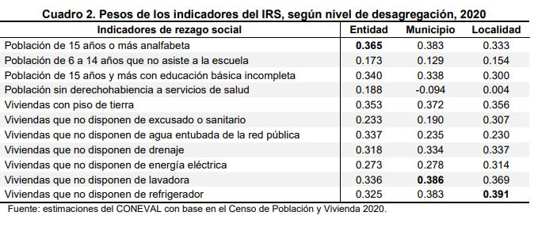

Descripción de la imagen

```r
knitr::include_graphics("Capture1.jpg")
```

# Cargamos los paquetes

```r
library(pacman)
p_load(haven,readxl,ggplot2,lavaan,descr,semTools,semPlot)
```

# Cargamos los datos

```r
Rs<-read_xlsx("RezagoSocial2020.xlsx")
```

Revisamos la base de datos. Las variables que usaremos son las del índice.

```r
names(Rs)
```

```
##  [1] "Mun"                          "Ent"
##  [3] "PobAnalfabeta15m"             "Poblacion6a14noasisteescuela"
##  [5] "Pob15msineducbasicacompleta"  "Poblacionsinderechoasalud"
##  [7] "ViviendasPisoTierra"          "ViviendassinExcusado"
##  [9] "Viviendassinaguaentubada"     "Viviendassindrenaje"
## [11] "Viviendassinenergiaelect"     "Viviendassinlavadora"
## [13] "Viviendassinrefrigerador"     "IndiceRezago"
```

Seleccionamos las variables del índice de rezago social para la estimación

```r
D <- Rs[, 3:13]
```

# Especificación del modelo CFA

Definimos un modelo unidimensional **Rezago Social** que es medido por los 11 indicadores.

**Sintaxis lavaan:**

- `=~` significa “medido por” (define indicadores de un factor latente)
- `~~` se usa para covarianzas entre factores (opcional)
- `~` se usa para regresiones

```r
modelo <- '
  RezagoSocial =~ PobAnalfabeta15m + Poblacion6a14noasisteescuela +
                  Pob15msineducbasicacompleta + Poblacionsinderechoasalud +
                  ViviendasPisoTierra + ViviendassinExcusado +
                  Viviendassinaguaentubada + Viviendassindrenaje +
                  Viviendassinenergiaelect + Viviendassinlavadora +
                  Viviendassinrefrigerador
'
```

Estimamos el modelo con la función cfa del paquete `lavaan`.

```r
# Estimador MLR es robusto ante no normalidad
ajuste <- cfa(modelo, data = D, estimator = "MLR")
```

Damos un vistazo al ajuste del modelo

```r
summary(ajuste, fit.measures = TRUE, standardized = TRUE, rsquare = TRUE)
```

```
## lavaan 0.6-19 ended normally after 57 iterations
##
##   Estimator                                         ML
##   Optimization method                           NLMINB
##   Number of model parameters                        22
##
##   Number of observations                          2469
##
## Model Test User Model:
##                                               Standard      Scaled
##   Test Statistic                              3210.217    1549.163
##   Degrees of freedom                                44          44
##   P-value (Chi-square)                           0.000       0.000
##   Scaling correction factor                                  2.072
##     Yuan-Bentler correction (Mplus variant)
##
## Model Test Baseline Model:
##
##   Test statistic                             15168.180    6973.793
##   Degrees of freedom                                55          55
##   P-value                                        0.000       0.000
##   Scaling correction factor                                  2.175
##
## User Model versus Baseline Model:
##
##   Comparative Fit Index (CFI)                    0.790       0.782
##   Tucker-Lewis Index (TLI)                       0.738       0.728
##
##   Robust Comparative Fit Index (CFI)                         0.793
##   Robust Tucker-Lewis Index (TLI)                            0.741
##
## Loglikelihood and Information Criteria:
##
##   Loglikelihood user model (H0)             -93320.490  -93320.490
##   Scaling correction factor                                  5.528
##       for the MLR correction
##   Loglikelihood unrestricted model (H1)     -91715.382  -91715.382
##   Scaling correction factor                                  3.224
##       for the MLR correction
##
```

[output cut: 56 more lines]

```
##     RezagoSocial     38.827    2.171   17.886    0.000    1.000    1.000
##
## R-Square:
##                    Estimate
##     PobAnalfabt15m    0.667
##     Pblcn614nsstsc    0.036
##     Pb15msndcbsccm    0.477
##     Pblcnsndrchsld    0.028
##     ViviendasPsTrr    0.639
##     VivindssnExcsd    0.096
##     Vivindssngntbd    0.183
##     Viviendssndrnj    0.471
##     Vivndssnnrglct    0.243
##     Viviendssnlvdr    0.853
##     Vvndssnrfrgrdr    0.828
```

## Índices de ajuste del modelo

```r
fitmeasures(ajuste, c("chisq.scaled", "df", "pvalue.scaled",
                      "cfi.robust", "tli.robust",
                      "rmsea.robust", "rmsea.ci.lower.robust", "rmsea.ci.upper.robust",
                      "srmr", "aic", "bic"))
```

```
##          chisq.scaled                    df         pvalue.scaled
##              1549.163                44.000                 0.000
##            cfi.robust            tli.robust          rmsea.robust
##                 0.793                 0.741                 0.169
## rmsea.ci.lower.robust rmsea.ci.upper.robust                  srmr
##                 0.162                 0.177                 0.082
##                   aic                   bic
##            186684.981            186812.836
```

# Cargas factoriales estandarizadas

```r
standardizedSolution(ajuste)
```

```
##                             lhs op                          rhs est.std    se
## 1                  RezagoSocial =~             PobAnalfabeta15m   0.817 0.010
## 2                  RezagoSocial =~ Poblacion6a14noasisteescuela   0.190 0.030
## 3                  RezagoSocial =~  Pob15msineducbasicacompleta   0.691 0.013
## 4                  RezagoSocial =~    Poblacionsinderechoasalud  -0.169 0.021
## 5                  RezagoSocial =~          ViviendasPisoTierra   0.799 0.011
## 6                  RezagoSocial =~         ViviendassinExcusado   0.309 0.024
## 7                  RezagoSocial =~     Viviendassinaguaentubada   0.428 0.020
## 8                  RezagoSocial =~          Viviendassindrenaje   0.686 0.013
## 9                  RezagoSocial =~     Viviendassinenergiaelect   0.493 0.016
## 10                 RezagoSocial =~         Viviendassinlavadora   0.923 0.005
## 11                 RezagoSocial =~     Viviendassinrefrigerador   0.910 0.006
## 12             PobAnalfabeta15m ~~             PobAnalfabeta15m   0.333 0.017
## 13 Poblacion6a14noasisteescuela ~~ Poblacion6a14noasisteescuela   0.964 0.011
## 14  Pob15msineducbasicacompleta ~~  Pob15msineducbasicacompleta   0.523 0.018
```

[output cut: 33 more lines]

**Interpretación:**

- Cargas > 0.70 son excelentes
- Cargas entre 0.50-0.70 son aceptables
- Cargas < 0.50 indican que el indicador mide débilmente el constructo

# Análisis de confiabilidad ¿Tiene sentido?

```r
compRelSEM(ajuste)
```

```
## RezagoSocial
##        0.902
```

# Índices de modificación

Si el ajuste no es adecuado, los índices de modificación sugieren cambios para mejorar el modelo.

```r
modindices(ajuste, sort = TRUE, maximum.number = 10)
```

```
##                             lhs op                          rhs      mi     epc
## 78         Viviendassinlavadora ~~     Viviendassinrefrigerador 934.872 102.616
## 25             PobAnalfabeta15m ~~  Pob15msineducbasicacompleta 811.993  28.443
## 66         ViviendassinExcusado ~~     Viviendassinenergiaelect 359.751   5.123
## 34 Poblacion6a14noasisteescuela ~~  Pob15msineducbasicacompleta 341.055  13.103
## 24             PobAnalfabeta15m ~~ Poblacion6a14noasisteescuela 216.336   4.701
## 41 Poblacion6a14noasisteescuela ~~         Viviendassinlavadora 172.449 -10.079
## 33             PobAnalfabeta15m ~~     Viviendassinrefrigerador 149.016 -13.281
## 76     Viviendassinenergiaelect ~~         Viviendassinlavadora 142.455  -6.828
## 50  Pob15msineducbasicacompleta ~~     Viviendassinrefrigerador 139.790 -26.484
## 61          ViviendasPisoTierra ~~     Viviendassinenergiaelect 139.689   3.325
##    sepc.lv sepc.all sepc.nox
## 78 102.616    1.310    1.310
## 25  28.443    0.638    0.638
## 66   5.123    0.387    0.387
## 34  13.103    0.383    0.383
## 24   4.701    0.316    0.316
## 41 -10.079   -0.327   -0.327
## 33 -13.281   -0.351   -0.351
## 76  -6.828   -0.305   -0.305
## 50 -26.484   -0.304   -0.304
## 61   3.325    0.255    0.255
```

**Interpretación:**

- **mi:** Reducción esperada en chi-cuadrado si se libera ese parámetro
- Solo modificar el modelo si tiene sentido teórico
- No modificar el modelo solo por mejorar índices de ajuste